# Predicting Game Success with Linear Regression

August 4, 2023

# Introduction

In this study, I will attempt to build a model that effectively predicts a video game’s Metacritic score available in the Steam game distribution dataset. Metacritic is a popular game review site that is trusted to provide accurate ratings for a wide variety of games. Using the available predictors in the dataset, my goal is to create a model that both passes linearity assumptions and obtains low test RMSE.

The data collection process for the dataset in this study involved extracting information from Steam’s website, which is a widely used digital gaming platform offering a diverse range of games available in one centralized location. The dataset is available on Kaggle at the following link: https://www.kaggle.com/datasets/mexwell/steamgames.

The data file `games.csv` contains 71716 observations and 39 variables. The variables include various metrics on game statistics, player engagement, and reviews. They contain both numeric and categorical variables.

I hope to explore the relationship of game characteristics, player engagement and their influence on critical reception. I chose this dataset because I enjoy playing games on Steam and am interested to see what factors are correlated with critic scores, especially for games I currently play. Since Steam is one of the more popular and widely used game distributors, I found it appropriate to choose this platform to explore my interest.

# Methods

Library imports

```r
library(lmtest)
library(readr)
library(knitr)
library(faraway)
library(stringr)
```

To begin the Steam database study, the CSV dataset is first read and copied into a tibble.

```r
# Reading in dataset from CSV file
games = read_csv('games.csv')
```

Relevant Variables:

The dataset as downloaded from the website needs initial cleaning to be usable. There are a few Unicode encoding problems with text fields in the dataset. Thankfully, text fields are not necessary for the model so I remove the problem text columns.

```r
games = games[c('Estimated owners', 'Peak CCU', 'Required age', 'Price', 'DLC count', 'Mac', 'Linux', 'Metacritic score', 'Recommendations', 'Average playtime forever', 'Median playtime forever')]
```

Additionally, all entries with Metacritic scores of zero are removed since those are games that will not provide any meaningful data for training. Spaces in column names are replaced with periods, the Estimated.owners column is consolidated and the Estimated.owners, Mac and Linux columns are converted to factors.

```r
# Removal of Metacritic scores of 0
games = games[games$`Metacritic score` > 0, ]

# Replace all spaces with periods in column names
names(games) = str_replace_all(names(games), c(" " = "."))

# Make new column consolidating Estimated Owners
games$Estimated.owners[games$Estimated.owners %in% c("0 - 0", "0 - 20000", "20000 - 50000", "50000 - 100000")] = "0-100k"
games$Estimated.owners[games$Estimated.owners %in% c("100000 - 200000", "200000 - 500000", "500000 - 1000000")] = "100k-1m"
games$Estimated.owners[games$Estimated.owners %in% c("1000000 - 2000000", "2000000 - 5000000", "5000000 - 10000000")] = "1m-10m"
games$Estimated.owners[games$Estimated.owners %in% c("10000000 - 20000000", "20000000 - 50000000", "50000000 - 100000000", "100000000 - 200000000")] = "10m-200m"

# Convert Estimated.owners, Mac and Linux to factor
games$Estimated.owners = as.factor(games$Estimated.owners)
games$Mac = as.factor(games$Mac)
games$Linux = as.factor(games$Linux)
```

To make certain actions more user friendly three functions are defined: `boxinvTransform`, `diagnostics` `plot_diag`. `boxinvTransform` takes a value and lambda and returns the inverted Box-Cox transformation. The `diagnostics` function takes a model and returns relevant diagnostic tests about the model including Train RMSE, Test RMSE, LOOCV, AIC, Adjusted R^2, BP test and Shapiro-Wilk test. Finally, the function `plot_diag` is defined to plot Fitted vs. Residual and Q-Q plots.

```r
boxinvTransform <- function(y, lambda) {
  if (lambda == 0L) { exp(y) }
  else { (y * lambda + 1)^(1/lambda) }
}
```

```r
# Diagnostics for:
# Train RMSE, Test RMSE, AIC, LOOCV, Adj R^2, BP test and Shapiro Test
diagnostics = function(model, trfm = TRUE) {
  fits = fitted(model)
  predictions = predict(model, games_tst)

  filter = predictions >= 0
  predictions = predictions[filter]

  if(trfm){
    fits = boxinvTransform(fits, 2.9)
    predictions = boxinvTransform(predictions, 2.9)
  }

  train_rmse = sqrt(sum((games_trn$Metacritic.score - fits) ^ 2) / length(fits))
  test_rmse = sqrt(sum((games_tst$Metacritic.score[filter] - predictions) ^ 2) / length(predictions))

  resid = ifelse(trfm, boxinvTransform(abs(resid(model)), 2.9), resid(model))
  loocv = sqrt(mean((resid / (1 - hatvalues(model))) ^ 2))

  data.frame(
    "train_rmse" = train_rmse,
    "test_rmse" = test_rmse,
    "aic" = extractAIC(model)[2],
    "LOOCV" = loocv,
    "adjR2" = summary(model)$adj.r.squared,
    "bp" = bptest(model)$p.value,
    "sw" = shapiro.test(resid(model))$p.value
  )
}
```

```r
# Function to plot Fitted vs. Residuals graph from model
plot_diag = function(model, pcol, lcol) {
  par(mfrow = c(1, 2))
  plot(fitted(model), resid(model),
       col = pcol,
       pch = 20,
       xlab = "Fitted",
       ylab = "Residual",
       main = "Fitted versus Residuals")
  abline(h = 0, col = lcol, lwd = 2)
  qqnorm(resid(model), col = pcol)
  qqline(resid(model), lty = 2, lwd = 2, col = lcol)
  par(mfrow = c(1,1))
}
```

The dataset is split into a train and test dataset with an approximate 80/20 split.

```r
# Create test and train datasets
set.seed(67)

games_idx = sample(nrow(games), 3000)
games_trn = games[games_idx, ]
games_tst = games[-games_idx, ]
```

Models are defined in increasing order of complexity as new relationships are discovered about and among the data. Explanation of how I progressed through these models is covered in Discussion.

```r
# Model Exploration

# Small model for forward step function
model_small = lm((((Metacritic.score ^ 2.9) - 1) / 2.9) ~ 1, games_trn)

# Simple additive model
model_add = lm(Metacritic.score ~ ., games_trn)

# Added BoxCox
model_boxcox = lm((((Metacritic.score ^ 2.9) - 1) / 2.9) ~ ., games_trn)

# Adding necessary logs to predictors
model_log = lm((((Metacritic.score ^ 2.9) - 1) / 2.9) ~ Estimated.owners + log1p(Peak.CCU) + Required.age + log1p(Price) + DLC.count + Mac + Linux + log1p(Recommendations) + log1p(Average.playtime.forever) + log1p(Median.playtime.forever), games_trn)

# Adding interactions to above model
model_log_int = lm((((Metacritic.score ^ 2.9) - 1) / 2.9) ~ (Estimated.owners + log1p(Peak.CCU) + Required.age + log1p(Price) + DLC.count + Mac + Linux + log1p(Recommendations) + log1p(Average.playtime.forever) + log1p(Median.playtime.forever))^3, games_trn)

# Selective Removal of Predictors
model_reduced_log_int = lm((((Metacritic.score ^ 2.9) - 1) / 2.9) ~ (Estimated.owners + log1p(Peak.CCU) + DLC.count + log1p(Recommendations) + log1p(Average.playtime.forever) + log1p(Median.playtime.forever))^3, games_trn)
```

The final “best” model to answer the research question is defined below.

```r
# Final Model considered here
model_final = step(model_reduced_log_int, trace = 0)
```

Finally, tables and plots summarizing my findings are generated and displayed in the Results section.

```r
# Model Diagnostics Comparison
diag_table = rbind("Add" = diagnostics(model_add, trfm = FALSE),
                  "Boxcox" = diagnostics(model_boxcox),
                  "Log" = diagnostics(model_log),
                  "Log_int" = diagnostics(model_log_int),
                  "Reduced_log_int" = diagnostics(model_reduced_log_int),
                  "Final" = diagnostics(model_final))

# Anova Tests between models
anova(model_log, model_log_int)$p.value
anova(model_reduced_log_int, model_log_int)$p.value
anova(model_final, model_reduced_log_int)$p.value
anova(model_final, model_reduced_log_int)$p.value

# Fitted Vs. Residual Plot for Final Model
plot_diag(model_final, "dodgerblue", "coral3")

# Log Transformation Reasoning
par(mfrow = c(1,2))
plot(games$Metacritic.score ~ games$Recommendations,
      col = "coral",
      pch = 20,
      xlab = "Recommendations",
      ylab = "Metacritic.score",
      main = "Recommendations")
plot(games$Metacritic.score ~ log(games$Recommendations),
      col = "coral",
      pch = 20,
      xlab = "log(Recommendations)",
      ylab = "Metacritic.score",
      main = "log(Recommendations)")

plot(games$Metacritic.score ~ games$Peak.CCU,
      col = "lightblue",
      pch = 20,
      xlab = "Peak.CCU",
      ylab = "Metacritic.score",
      main = "Peak.CCU")
plot(games$Metacritic.score ~ log(games$Peak.CCU),
      col = "lightblue",
      pch = 20,
      xlab = "log(Peak.CCU)",
      ylab = "Metacritic.score",
      main = "log(Peak.CCU)")

plot(games$Metacritic.score ~ games$Average.playtime.forever,
      col = "orchid",
      pch = 20,
      xlab = "Average.playtime.forever",
      ylab = "Metacritic.score",
      main = "Average.playtime.forever")
plot(games$Metacritic.score ~ log(games$Average.playtime.forever),
      col = "orchid",
      pch = 20,
      xlab = "log(Average.playtime.forever)",
      ylab = "Metacritic.score",
      main = "log(Average.playtime.forever)")

plot(games$Metacritic.score ~ games$Median.playtime.forever,
      col = "brown",
      pch = 20,
      xlab = "Median.playtime.forever",
      ylab = "Metacritic.score",
      main = "Median.playtime.forever")
plot(games$Metacritic.score ~ log(games$Median.playtime.forever),
      col = "brown",
      pch = 20,
      xlab = "log(Median.playtime.forever)",
      ylab = "Metacritic.score",
      main = "log(Median.playtime.forever)")

par(mfrow = c(1,1))

#Outliers exploration
plot(fitted(model_final), resid(model_final),
       col = ifelse(hatvalues(model_final) > 2 * mean(hatvalues(model_final)), "red", "lightblue"),
       pch = 20,
       xlab = "Fitted",
       ylab = "Residual",
       main = "High Leverage Fitted versus Residuals")

plot(fitted(model_final), resid(model_final),
       col = ifelse(abs(rstandard(model_final)) > 2, "red", "lightblue"),
       pch = 20,
       xlab = "Fitted",
       ylab = "Residual",
       main = "Outliers Fitted versus Residuals")

plot(fitted(model_final), resid(model_final),
       col = ifelse(cooks.distance(model_final) > 4 / length(resid(model_final)), "red", "lightblue"),
       pch = 20,
       xlab = "Fitted",
       ylab = "Residual",
       main = "High Influence Fitted versus Residuals")
```

# Results

## Log Transformation Graphs

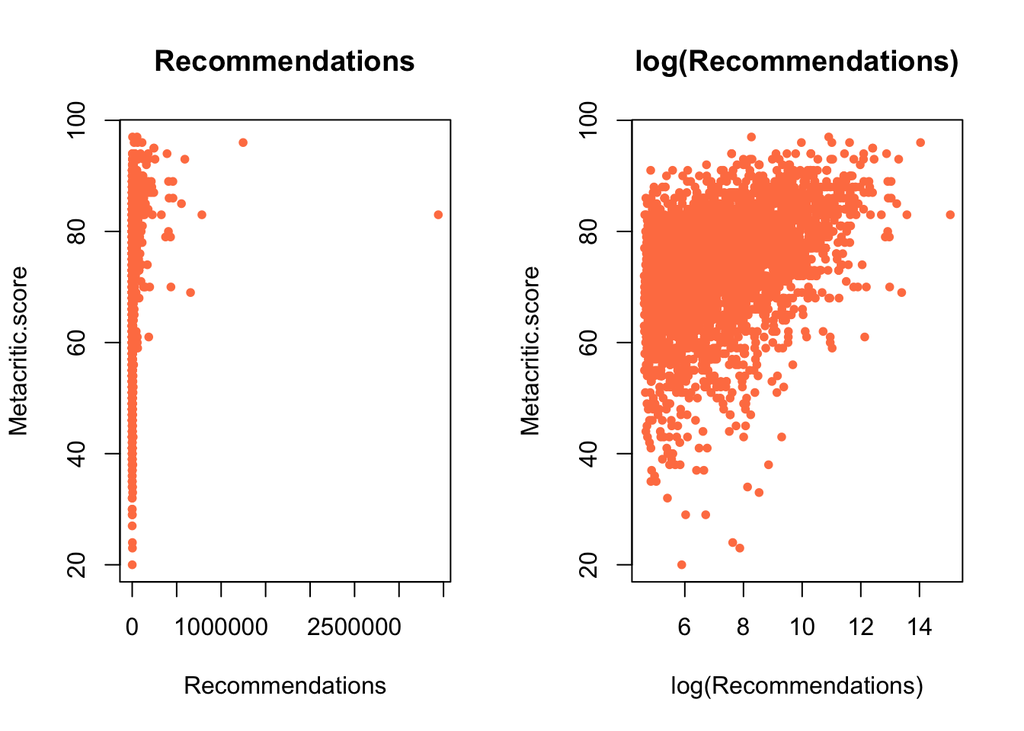

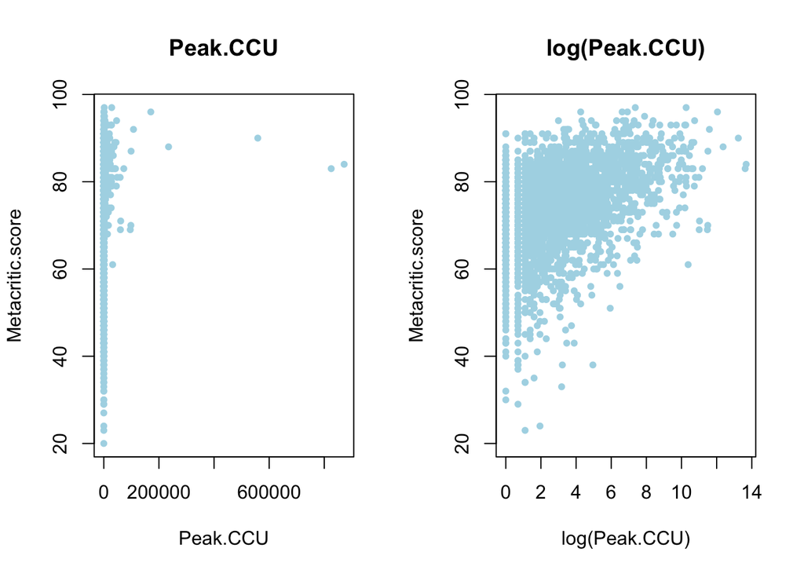

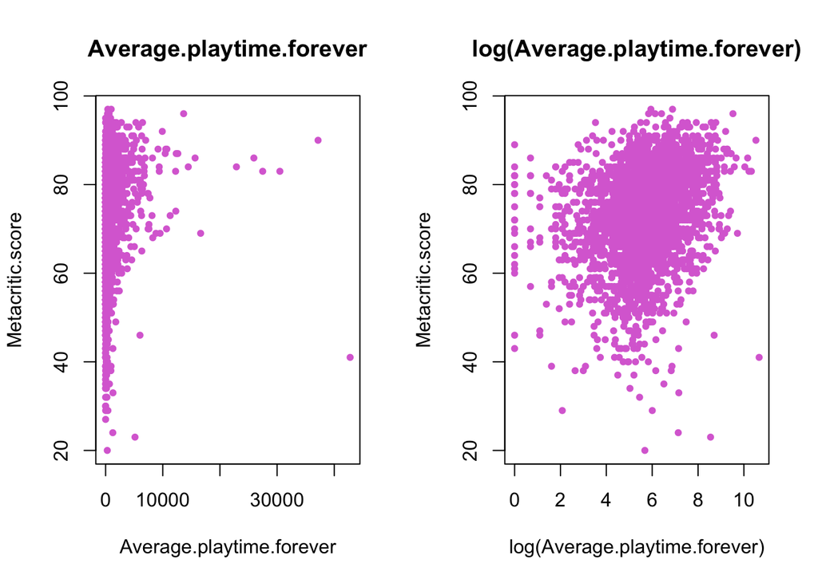

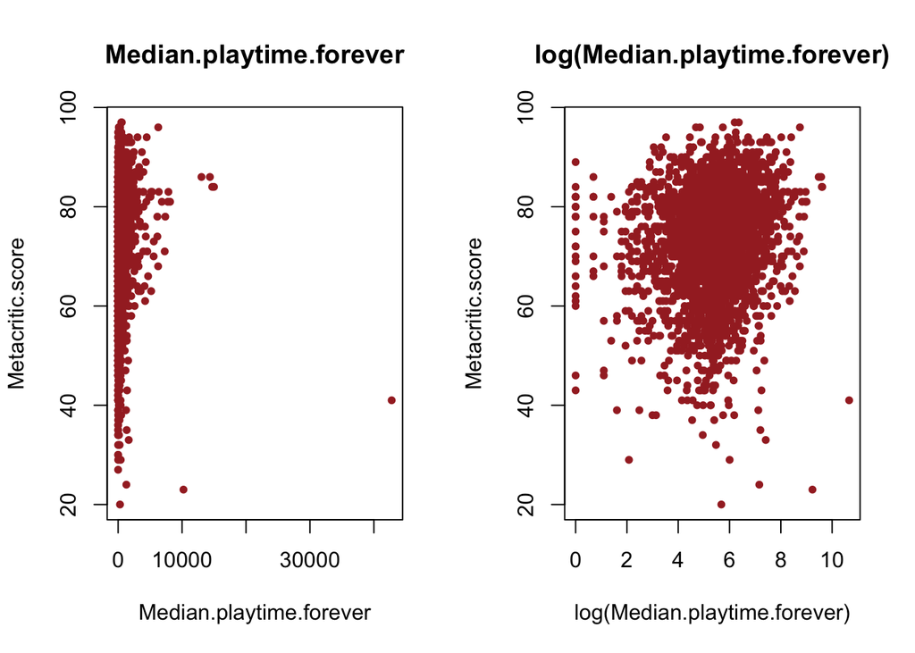

The above graphs show how the predictors Recommendations, Peak.CCU, Average.playtime.forever and Median.playtime.forever have scales across orders of magnitude and therefore need a log transformation to make them easier to work with.

## Model Diagnostic Comparisons

$\alpha$ = 0.05 for Model Assumptions

Model Diagnostics

|  | Train RMSE | Test RMSE | AIC | LOOCV | Adj R^2 | BP | SW |
| --- | --- | --- | --- | --- | --- | --- | --- |
| Add | 9.718 | 9.739 | 13670 | 13.62 | 0.1481 | 0.0000 | 0.0000 |
| Boxcox | 9.790 | 9.749 | 62028 | 56.32 | 0.1696 | 0.0000 | 0.0610 |
| Log | 9.296 | 9.364 | 61697 | 57.73 | 0.2565 | 0.0000 | 0.3586 |
| Log_int | 8.729 | 29051.019 | 61737 | Inf | 0.3023 | 0.3323 | 0.2702 |
| Reduced_log_int | 9.195 | 9.425 | 61713 | 90.69 | 0.2673 | 0.4475 | 0.3222 |
| Final | 9.218 | 9.518 | 61690 | 66.54 | 0.2678 | 0.1158 | 0.3259 |

The model diagnostic table shows the progression and improvement of models throughout the process of model building. Using an $\alpha$ of 0.05, the final model passes the BP and Shapiro test signifying no violations of model assumptions.

## Anova Tests

Since output of Anova tests are lengthy, only p-values are shown.

```r
anova(model_log, model_log_int)[2, "Pr(>F)"]
```

```
## [1] 4.306e-12
```

```r
anova(model_reduced_log_int, model_log_int)[2, "Pr(>F)"]
```

```
## [1] 9.144e-10
```

```r
anova(model_final, model_reduced_log_int)[2, "Pr(>F)"]
```

```
## [1] 0.5839
```

The anova tests above, with an $\alpha$ value of 0.05, show log transformations and interactions are necessary. Additionally, the smaller final model is preferred over the larger interactive model.

## Model Assumption Plots

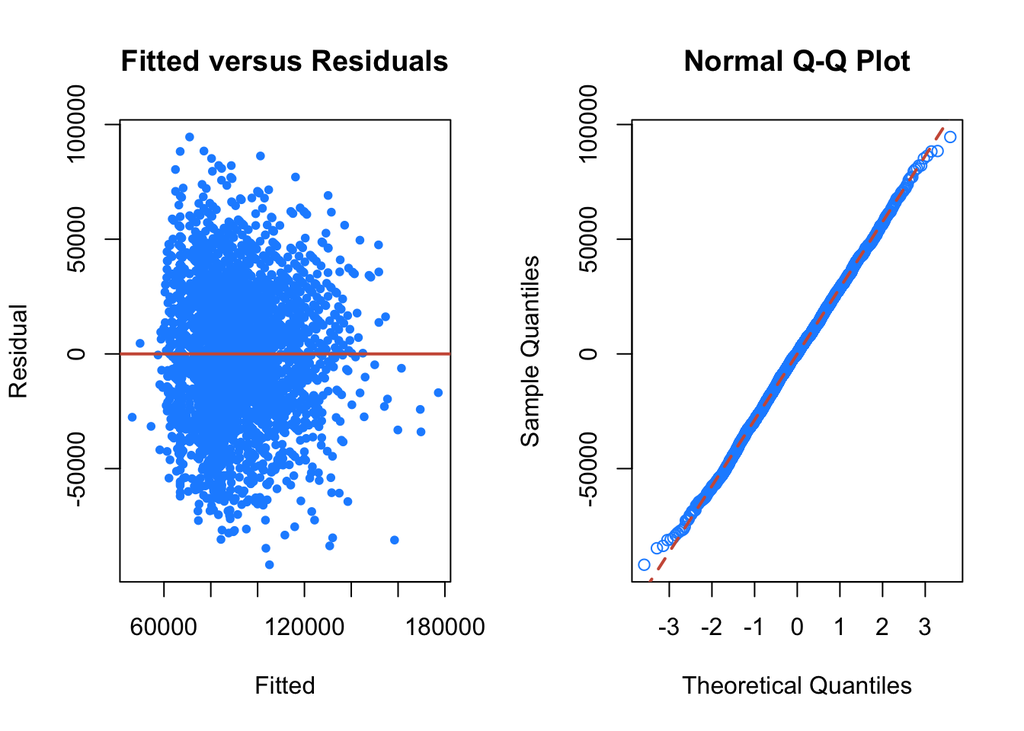

The final model Fitted vs. Residuals plot has a mean around zero so the linearity assumption is valid and the spread of the residuals is roughly even so the constant variance assumption is valid. The Q-Q plot is very close to the line and there are minimal tailing so the normality assumption is valid.

## Outlier Exploration

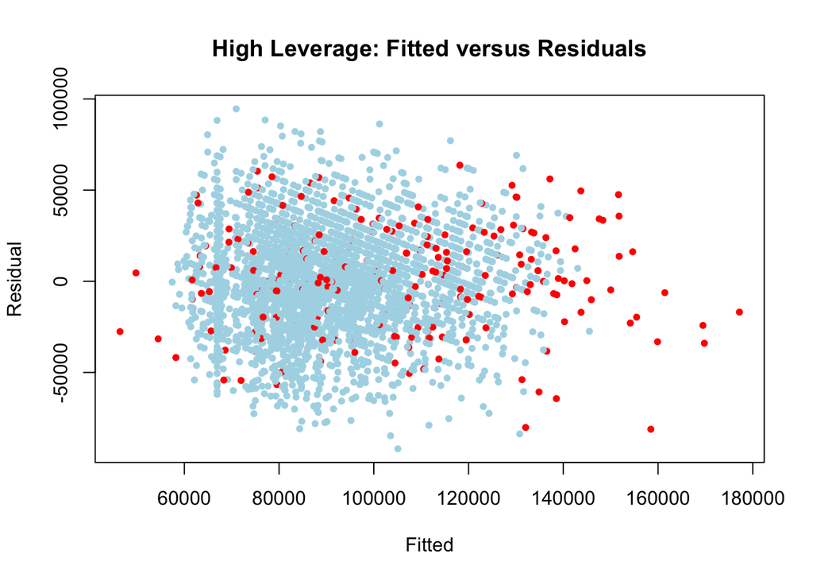

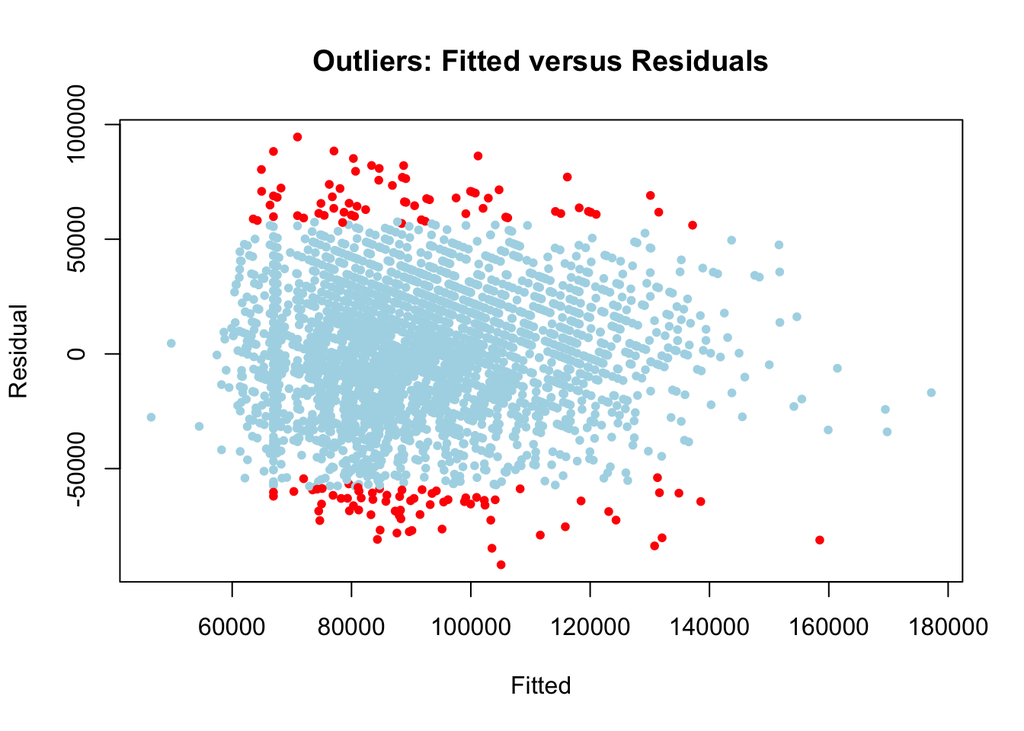

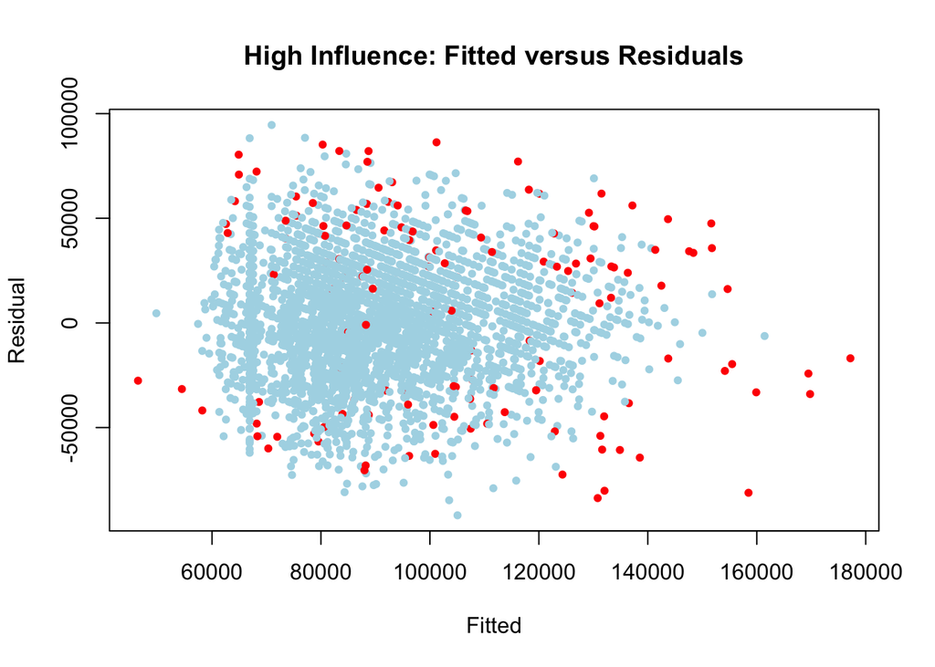

The above graphs visually illustrate the observations that have high leverage, influence or are outliers in the final model.

## Collinearity

```r
sum(vif(model_final) > 5)
```

```
## [1] 51
```

Using the heuristic that having a variance inflation factor greater than 5 is high, 51 predictors are collinear.

## Final Model Diagnostics

Final Model Diagnostics

|  | Train RMSE | Test RMSE | AIC | LOOCV | Adj R^2 | BP | SW |
| --- | --- | --- | --- | --- | --- | --- | --- |
| Final | 9.218 | 9.518 | 61690 | 66.54 | 0.2678 | 0.1158 | 0.3259 |

# Discussion

I started with an additive model `Add` including all predictors, but the null hypothesis of constant variance and normality is rejected.

In the model `Log`, I plotted log transformation graphs for each of the predictors and found that `Recommendations`, `Peak.CCU`, `Average.playtime.forever`, and `Median.playtime.forever` crossed multiple scales of magnitude, which required log transformations. This greatly improved the adjusted r squared and the train and test RMSE values.

I then added all two-way and three-way interactions with the Box-Cox transformation on the response and log transformations on the mentioned predictors in the model `Log_int`, which finally failed to reject the null hypothesis of the constant variance assumption, but drastically overfit the data, evidenced by the small train RMSE, large test RMSE, and large LOOCV-RMSE.

Looking at the summary of the previously constructed model, I manually selected non-significant variables to remove one-by-one to assess their effect on the diagnostics in model `Reduced_log_int`. This failed to reject the null hypotheses of the constant variance and normality assumptions, as well as modeled the data without overfitting.

I chose this final model because other combinations of predictors would violate the constant variance and normality assumptions, worsen the test RMSE, or overfit the data. This model was the most successful at balancing between these different considerations.

With the final model, I performed an exploration for leverage, outliers, and influence (included in the appendix). When I attempted to fit a model with influential points removed, it achieved a better adjusted r squared, however it violated the constant variance assumption, as well as overfit the data with a very high LOOCV-RMSE. Therefore, I chose to not remove influential points from the final model.

I found that 51 predictors (all predictors) in the final model are collinear. Even though collinearity has a large negative effect on estimation and inference, I still proceeded to choose this model since it has no effect on prediction.

The original goal was if I could predict Metacritic score from the Steam dataset. Because of the number of predictors in the model and its multicollinearity, it is not useful for explanation; however, it is acceptable at predicting Metacritic score from the other data available in the Steam dataset. With a test RMSE of 9.5176 for the final model, it will not always predict the exact Metacritic score but will provide a good estimation.

# Appendix

## Supplemental Code

Code used to discover predictors that needed transformation.

```r
# Why I chose logs
plot((((Metacritic.score ^ 2.9) - 1) / 2.9) ~ Estimated.owners, games_trn)
plot((((Metacritic.score ^ 2.9) - 1) / 2.9) ~ Required.age, games_trn)
plot((((Metacritic.score ^ 2.9) - 1) / 2.9) ~ log(Price), games_trn)
plot((((Metacritic.score ^ 2.9) - 1) / 2.9) ~ Mac, games_trn)
plot((((Metacritic.score ^ 2.9) - 1) / 2.9) ~ log(Median.playtime.forever), games_trn)
```

Code used to explore the effect of influential point removal.

```r
filter = !is.nan(cooks.distance(model_reduced_log_int))

games_trn_remove_cooks = games_trn[cooks.distance(model_reduced_log_int) <= 4 / (length(cooks.distance(model_reduced_log_int))),]

model_remove_cooks = lm((((Metacritic.score ^ 2.9) - 1) / 2.9) ~ (Estimated.owners + log1p(Peak.CCU) + DLC.count + log1p(Recommendations) + log1p(Average.playtime.forever) + log1p(Median.playtime.forever))^3, games_trn_remove_cooks)

diagnostics(step(model_remove_cooks, trace = 0))
```

```
##    train_rmse test_rmse   aic LOOCV  adjR2       bp     sw
## BP      11.86     15.76 58583   Inf 0.2725 0.007232 0.2498
```